# Risk Factor Analysis

## Outcome Variable

**Outcome Variable:** haz

## Predictor Variables

**Intervention Variable:** predexfd6

**Adjustment Set:**

- arm
- sex
- brthmon
- W_mage
- meducyrs
- feducyrs
- hhwealth_quart
- hfoodsec
- W_mhtcm
- W_mwtkg
- W_mbmi
- vagbrth
- W_gagebrth
- W_birthwt
- W_birthlen
- W_nrooms
- W_nchldlt5
- month
- W_parity
- impfloor
- impsan
- safeh20
- delta_W_mage
- delta_meducyrs
- delta_feducyrs
- delta_hhwealth_quart
- delta_hfoodsec
- delta_W_mhtcm
- delta_W_mwtkg
- delta_W_mbmi
- delta_vagbrth
- delta_W_gagebrth
- delta_W_birthwt
- delta_W_birthlen
- delta_W_nrooms
- delta_W_nchldlt5
- delta_month
- delta_W_parity
- delta_impfloor
- delta_impsan
- delta_safeh20

## Stratifying Variables

The analysis was stratified on these variable(s):

- agecat
- studyid
- country

## Data Summary

| agecat | studyid | country | predexfd6 | n_cell | n | outcome_variable |
| --- | --- | --- | --- | --- | --- | --- |
| Birth | ki0047075b-MAL-ED | BANGLADESH | 1 | 72 | 205 | haz |
| Birth | ki0047075b-MAL-ED | BANGLADESH | 0 | 133 | 205 | haz |
| Birth | ki0047075b-MAL-ED | BRAZIL | 1 | 6 | 60 | haz |
| Birth | ki0047075b-MAL-ED | BRAZIL | 0 | 54 | 60 | haz |
| Birth | ki0047075b-MAL-ED | INDIA | 1 | 4 | 39 | haz |
| Birth | ki0047075b-MAL-ED | INDIA | 0 | 35 | 39 | haz |
| Birth | ki0047075b-MAL-ED | NEPAL | 1 | 3 | 24 | haz |
| Birth | ki0047075b-MAL-ED | NEPAL | 0 | 21 | 24 | haz |
| Birth | ki0047075b-MAL-ED | PERU | 1 | 73 | 213 | haz |
| Birth | ki0047075b-MAL-ED | PERU | 0 | 140 | 213 | haz |
| Birth | ki0047075b-MAL-ED | SOUTH AFRICA | 1 | 1 | 91 | haz |
| Birth | ki0047075b-MAL-ED | SOUTH AFRICA | 0 | 90 | 91 | haz |
| Birth | ki0047075b-MAL-ED | TANZANIA, UNITED REPUBLIC OF | 1 | 0 | 113 | haz |
| Birth | ki0047075b-MAL-ED | TANZANIA, UNITED REPUBLIC OF | 0 | 113 | 113 | haz |
| Birth | ki1000108-CMC-V-BCS-2002 | INDIA | 1 | 7 | 7 | haz |
| Birth | ki1000108-CMC-V-BCS-2002 | INDIA | 0 | 0 | 7 | haz |
| Birth | ki1000108-IRC | INDIA | 1 | 0 | 14 | haz |
| Birth | ki1000108-IRC | INDIA | 0 | 14 | 14 | haz |
| Birth | ki1000109-EE | PAKISTAN | 1 | 38 | 42 | haz |
| Birth | ki1000109-EE | PAKISTAN | 0 | 4 | 42 | haz |
| Birth | ki1000304b-SAS-CompFeed | INDIA | 1 | 346 | 364 | haz |
| Birth | ki1000304b-SAS-CompFeed | INDIA | 0 | 18 | 364 | haz |
| Birth | ki1017093b-PROVIDE | BANGLADESH | 1 | 159 | 539 | haz |
| Birth | ki1017093b-PROVIDE | BANGLADESH | 0 | 380 | 539 | haz |
| Birth | ki1101329-Keneba | GAMBIA | 1 | 485 | 1403 | haz |
| Birth | ki1101329-Keneba | GAMBIA | 0 | 918 | 1403 | haz |
| Birth | ki1113344-GMS-Nepal | NEPAL | 1 | 419 | 563 | haz |
| Birth | ki1113344-GMS-Nepal | NEPAL | 0 | 144 | 563 | haz |
| Birth | kiGH5241-JiVitA-3 | BANGLADESH | 1 | 10466 | 13423 | haz |
| Birth | kiGH5241-JiVitA-3 | BANGLADESH | 0 | 2957 | 13423 | haz |

[output cut: 70 more lines]

The following strata were considered:

- agecat: 24 months, studyid: ki0047075b-MAL-ED, country: BANGLADESH
- agecat: 24 months, studyid: ki0047075b-MAL-ED, country: BRAZIL
- agecat: 24 months, studyid: ki0047075b-MAL-ED, country: INDIA
- agecat: 24 months, studyid: ki0047075b-MAL-ED, country: NEPAL
- agecat: 24 months, studyid: ki0047075b-MAL-ED, country: PERU
- agecat: 24 months, studyid: ki0047075b-MAL-ED, country: SOUTH AFRICA
- agecat: 24 months, studyid: ki0047075b-MAL-ED, country: TANZANIA, UNITED REPUBLIC OF
- agecat: 24 months, studyid: ki1000108-CMC-V-BCS-2002, country: INDIA
- agecat: 24 months, studyid: ki1000108-IRC, country: INDIA
- agecat: 24 months, studyid: ki1000109-EE, country: PAKISTAN
- agecat: 24 months, studyid: ki1017093b-PROVIDE, country: BANGLADESH
- agecat: 24 months, studyid: ki1101329-Keneba, country: GAMBIA
- agecat: 24 months, studyid: ki1113344-GMS-Nepal, country: NEPAL
- agecat: 24 months, studyid: ki1148112-LCNI-5, country: MALAWI
- agecat: 24 months, studyid: kiGH5241-JiVitA-3, country: BANGLADESH
- agecat: 24 months, studyid: kiGH5241-JiVitA-4, country: BANGLADESH
- agecat: 6 months, studyid: ki0047075b-MAL-ED, country: BANGLADESH
- agecat: 6 months, studyid: ki0047075b-MAL-ED, country: BRAZIL
- agecat: 6 months, studyid: ki0047075b-MAL-ED, country: INDIA
- agecat: 6 months, studyid: ki0047075b-MAL-ED, country: NEPAL
- agecat: 6 months, studyid: ki0047075b-MAL-ED, country: PERU
- agecat: 6 months, studyid: ki0047075b-MAL-ED, country: SOUTH AFRICA
- agecat: 6 months, studyid: ki0047075b-MAL-ED, country: TANZANIA, UNITED REPUBLIC OF
- agecat: 6 months, studyid: ki1000108-CMC-V-BCS-2002, country: INDIA
- agecat: 6 months, studyid: ki1000108-IRC, country: INDIA
- agecat: 6 months, studyid: ki1000109-EE, country: PAKISTAN
- agecat: 6 months, studyid: ki1000304b-SAS-CompFeed, country: INDIA
- agecat: 6 months, studyid: ki1000304b-SAS-FoodSuppl, country: INDIA
- agecat: 6 months, studyid: ki1017093b-PROVIDE, country: BANGLADESH
- agecat: 6 months, studyid: ki1101329-Keneba, country: GAMBIA
- agecat: 6 months, studyid: ki1113344-GMS-Nepal, country: NEPAL
- agecat: 6 months, studyid: ki1148112-LCNI-5, country: MALAWI
- agecat: 6 months, studyid: kiGH5241-JiVitA-3, country: BANGLADESH
- agecat: 6 months, studyid: kiGH5241-JiVitA-4, country: BANGLADESH
- agecat: Birth, studyid: ki0047075b-MAL-ED, country: BANGLADESH
- agecat: Birth, studyid: ki0047075b-MAL-ED, country: BRAZIL
- agecat: Birth, studyid: ki0047075b-MAL-ED, country: INDIA
- agecat: Birth, studyid: ki0047075b-MAL-ED, country: NEPAL
- agecat: Birth, studyid: ki0047075b-MAL-ED, country: PERU
- agecat: Birth, studyid: ki0047075b-MAL-ED, country: SOUTH AFRICA
- agecat: Birth, studyid: ki0047075b-MAL-ED, country: TANZANIA, UNITED REPUBLIC OF
- agecat: Birth, studyid: ki1000108-CMC-V-BCS-2002, country: INDIA
- agecat: Birth, studyid: ki1000108-IRC, country: INDIA
- agecat: Birth, studyid: ki1000109-EE, country: PAKISTAN
- agecat: Birth, studyid: ki1000304b-SAS-CompFeed, country: INDIA
- agecat: Birth, studyid: ki1017093b-PROVIDE, country: BANGLADESH
- agecat: Birth, studyid: ki1101329-Keneba, country: GAMBIA
- agecat: Birth, studyid: ki1113344-GMS-Nepal, country: NEPAL
- agecat: Birth, studyid: kiGH5241-JiVitA-3, country: BANGLADESH
- agecat: Birth, studyid: kiGH5241-JiVitA-4, country: BANGLADESH

### Dropped Strata

- agecat: Birth, studyid: ki0047075b-MAL-ED, country: INDIA
- agecat: Birth, studyid: ki0047075b-MAL-ED, country: NEPAL
- agecat: Birth, studyid: ki0047075b-MAL-ED, country: SOUTH AFRICA
- agecat: Birth, studyid: ki0047075b-MAL-ED, country: TANZANIA, UNITED REPUBLIC OF
- agecat: Birth, studyid: ki1000108-CMC-V-BCS-2002, country: INDIA
- agecat: Birth, studyid: ki1000108-IRC, country: INDIA
- agecat: Birth, studyid: ki1000109-EE, country: PAKISTAN
- agecat: 6 months, studyid: ki0047075b-MAL-ED, country: SOUTH AFRICA
- agecat: 6 months, studyid: ki0047075b-MAL-ED, country: TANZANIA, UNITED REPUBLIC OF
- agecat: 6 months, studyid: ki1000108-CMC-V-BCS-2002, country: INDIA
- agecat: 6 months, studyid: ki1000108-IRC, country: INDIA
- agecat: 6 months, studyid: ki1000304b-SAS-FoodSuppl, country: INDIA
- agecat: 24 months, studyid: ki0047075b-MAL-ED, country: SOUTH AFRICA
- agecat: 24 months, studyid: ki0047075b-MAL-ED, country: TANZANIA, UNITED REPUBLIC OF
- agecat: 24 months, studyid: ki1000108-CMC-V-BCS-2002, country: INDIA
- agecat: 24 months, studyid: ki1000108-IRC, country: INDIA
- agecat: 24 months, studyid: ki1000109-EE, country: PAKISTAN

## Methods Detail

We’re interested in the causal parameters $E[Y_a]$ for all values of $a \in \mathcal{A}$. These parameters represent the mean outcome if, possibly contrary to fact, we intervened to set all units to have $A=a$. Under the randomization and positivity assumptions, these are identified by the statistical parameters $\psi_a=E_W[E_{Y|A,W}(Y|A=a,W)]$. In addition, we’re interested in the mean of $Y$, $E[Y]$ under no intervention (the observed mean). We will estimate these parameters by using SuperLearner to fit the relevant likelihood factors – $E_{Y|A,W}(Y|A=a,W)$ and $p(A=a|W)$, and then updating our likelihood fit using a joint TMLE.

For unadjusted analyses ($W=\{\}$), initial likelihoods were estimated using Lrnr_glm to estimate the simple $E(Y|A)$ and Lrnr_mean to estimate $p(A)$. For adjusted analyses, a small library containing Lrnr_glmnet, Lrnr_xgboost, and Lrnr_mean was used.

Having estimated these parameters, we will then use the delta method to estimate relative risks and attributable risks relative to a prespecified baseline level of $A$.

# Results Detail

## Results Plots

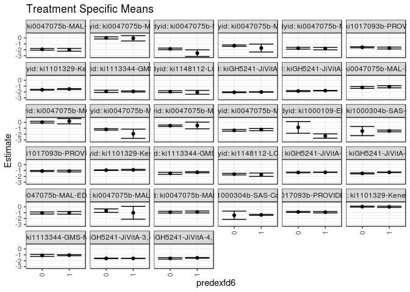

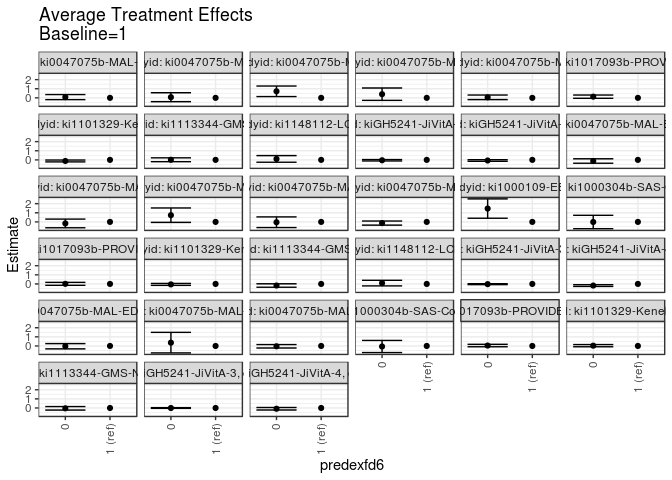

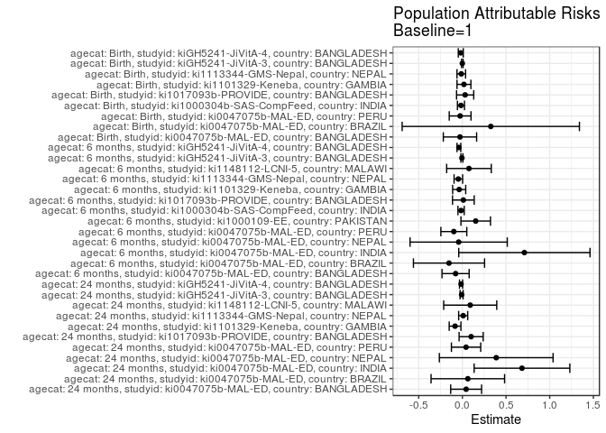

## Results Table

### Parameter: TSM

| agecat | studyid | country | intervention_level | baseline_level | estimate | ci_lower | ci_upper |
| --- | --- | --- | --- | --- | --- | --- | --- |
| Birth | ki0047075b-MAL-ED | BANGLADESH | 1 | NA | -1.0254522 | -1.2511631 | -0.7997413 |
| Birth | ki0047075b-MAL-ED | BANGLADESH | 0 | NA | -1.0561803 | -1.2353379 | -0.8770228 |
| Birth | ki0047075b-MAL-ED | BRAZIL | 1 | NA | -1.0216667 | -2.1085384 | 0.0652051 |
| Birth | ki0047075b-MAL-ED | BRAZIL | 0 | NA | -0.6601852 | -0.9595686 | -0.3608018 |
| Birth | ki0047075b-MAL-ED | PERU | 1 | NA | -0.8806956 | -1.0426517 | -0.7187396 |
| Birth | ki0047075b-MAL-ED | PERU | 0 | NA | -0.9179541 | -1.0644606 | -0.7714476 |
| Birth | ki1000304b-SAS-CompFeed | INDIA | 1 | NA | -1.3776197 | -1.4631704 | -1.2920690 |
| Birth | ki1000304b-SAS-CompFeed | INDIA | 0 | NA | -1.4364436 | -2.1366347 | -0.7362525 |
| Birth | ki1017093b-PROVIDE | BANGLADESH | 1 | NA | -0.9167975 | -1.0384144 | -0.7951806 |
| Birth | ki1017093b-PROVIDE | BANGLADESH | 0 | NA | -0.8721206 | -0.9588060 | -0.7854353 |
| Birth | ki1101329-Keneba | GAMBIA | 1 | NA | -0.0053732 | -0.1116550 | 0.1009085 |
| Birth | ki1101329-Keneba | GAMBIA | 0 | NA | 0.0263032 | -0.0524682 | 0.1050747 |
| Birth | ki1113344-GMS-Nepal | NEPAL | 1 | NA | -1.0514698 | -1.1486555 | -0.9542841 |
| Birth | ki1113344-GMS-Nepal | NEPAL | 0 | NA | -1.0890930 | -1.2634383 | -0.9147477 |
| Birth | kiGH5241-JiVitA-3 | BANGLADESH | 1 | NA | -1.5948124 | -1.6196041 | -1.5700208 |
| Birth | kiGH5241-JiVitA-3 | BANGLADESH | 0 | NA | -1.5984238 | -1.6377068 | -1.5591409 |
| Birth | kiGH5241-JiVitA-4 | BANGLADESH | 1 | NA | -1.5090609 | -1.5613717 | -1.4567501 |
| Birth | kiGH5241-JiVitA-4 | BANGLADESH | 0 | NA | -1.5942252 | -1.7217593 | -1.4666911 |
| 6 months | ki0047075b-MAL-ED | BANGLADESH | 1 | NA | -1.1122668 | -1.2983591 | -0.9261744 |
| 6 months | ki0047075b-MAL-ED | BANGLADESH | 0 | NA | -1.2358719 | -1.3925244 | -1.0792193 |
| 6 months | ki0047075b-MAL-ED | BRAZIL | 1 | NA | 0.2008100 | -0.2495739 | 0.6511938 |
| 6 months | ki0047075b-MAL-ED | BRAZIL | 0 | NA | 0.0344076 | -0.1160045 | 0.1848196 |
| 6 months | ki0047075b-MAL-ED | INDIA | 1 | NA | -1.9289400 | -2.7117216 | -1.1461585 |
| 6 months | ki0047075b-MAL-ED | INDIA | 0 | NA | -1.1927246 | -1.3137337 | -1.0717155 |
| 6 months | ki0047075b-MAL-ED | NEPAL | 1 | NA | -0.5196406 | -1.0918487 | 0.0525675 |
| 6 months | ki0047075b-MAL-ED | NEPAL | 0 | NA | -0.5571452 | -0.6754578 | -0.4388326 |
| 6 months | ki0047075b-MAL-ED | PERU | 1 | NA | -1.2241524 | -1.3998407 | -1.0484642 |
| 6 months | ki0047075b-MAL-ED | PERU | 0 | NA | -1.3545675 | -1.4923557 | -1.2167792 |
| 6 months | ki1000109-EE | PAKISTAN | 1 | NA | -2.3121318 | -2.6865239 | -1.9377397 |
| 6 months | ki1000109-EE | PAKISTAN | 0 | NA | -0.8473333 | -1.8424880 | 0.1478213 |
| 6 months | ki1000304b-SAS-CompFeed | INDIA | 1 | NA | -1.4549959 | -1.6008850 | -1.3091069 |
| 6 months | ki1000304b-SAS-CompFeed | INDIA | 0 | NA | -1.4654856 | -2.2428805 | -0.6880907 |
| 6 months | ki1017093b-PROVIDE | BANGLADESH | 1 | NA | -1.1029500 | -1.2387002 | -0.9671997 |
| 6 months | ki1017093b-PROVIDE | BANGLADESH | 0 | NA | -1.0930412 | -1.1810108 | -1.0050716 |
| 6 months | ki1101329-Keneba | GAMBIA | 1 | NA | -0.8965261 | -0.9863740 | -0.8066783 |
| 6 months | ki1101329-Keneba | GAMBIA | 0 | NA | -0.9480114 | -1.0071358 | -0.8888870 |
| 6 months | ki1113344-GMS-Nepal | NEPAL | 1 | NA | -1.3078298 | -1.3966509 | -1.2190086 |
| 6 months | ki1113344-GMS-Nepal | NEPAL | 0 | NA | -1.4819035 | -1.6497187 | -1.3140883 |
| 6 months | ki1148112-LCNI-5 | MALAWI | 1 | NA | -1.7149942 | -1.9966387 | -1.4333497 |
| 6 months | ki1148112-LCNI-5 | MALAWI | 0 | NA | -1.6229426 | -1.7548544 | -1.4910308 |
| 6 months | kiGH5241-JiVitA-3 | BANGLADESH | 1 | NA | -1.3084363 | -1.3388725 | -1.2780002 |
| 6 months | kiGH5241-JiVitA-3 | BANGLADESH | 0 | NA | -1.3332539 | -1.3825594 | -1.2839484 |
| 6 months | kiGH5241-JiVitA-4 | BANGLADESH | 1 | NA | -1.3083159 | -1.3492760 | -1.2673557 |
| 6 months | kiGH5241-JiVitA-4 | BANGLADESH | 0 | NA | -1.4872775 | -1.5763267 | -1.3982282 |
| 24 months | ki0047075b-MAL-ED | BANGLADESH | 1 | NA | -2.0007550 | -2.2370832 | -1.7644267 |
| 24 months | ki0047075b-MAL-ED | BANGLADESH | 0 | NA | -1.9170991 | -2.0646194 | -1.7695789 |
| 24 months | ki0047075b-MAL-ED | BRAZIL | 1 | NA | -0.0562551 | -0.5091302 | 0.3966200 |
| 24 months | ki0047075b-MAL-ED | BRAZIL | 0 | NA | 0.0161764 | -0.1677058 | 0.2000587 |
| 24 months | ki0047075b-MAL-ED | INDIA | 1 | NA | -2.5688710 | -3.1315736 | -2.0061684 |
| 24 months | ki0047075b-MAL-ED | INDIA | 0 | NA | -1.8494960 | -1.9811780 | -1.7178141 |
| 24 months | ki0047075b-MAL-ED | NEPAL | 1 | NA | -1.7062757 | -2.3735552 | -1.0389961 |
| 24 months | ki0047075b-MAL-ED | NEPAL | 0 | NA | -1.3038073 | -1.4294132 | -1.1782014 |
| 24 months | ki0047075b-MAL-ED | PERU | 1 | NA | -1.7946625 | -1.9979017 | -1.5914233 |
| 24 months | ki0047075b-MAL-ED | PERU | 0 | NA | -1.7347966 | -1.8862066 | -1.5833867 |
| 24 months | ki1017093b-PROVIDE | BANGLADESH | 1 | NA | -1.7027143 | -1.8593148 | -1.5461138 |
| 24 months | ki1017093b-PROVIDE | BANGLADESH | 0 | NA | -1.5709840 | -1.6667845 | -1.4751835 |
| 24 months | ki1101329-Keneba | GAMBIA | 1 | NA | -1.5037165 | -1.5857116 | -1.4217213 |
| 24 months | ki1101329-Keneba | GAMBIA | 0 | NA | -1.6231135 | -1.6880452 | -1.5581818 |
| 24 months | ki1113344-GMS-Nepal | NEPAL | 1 | NA | -1.9095076 | -2.0047541 | -1.8142611 |
| 24 months | ki1113344-GMS-Nepal | NEPAL | 0 | NA | -1.8957536 | -2.0870660 | -1.7044413 |
| 24 months | ki1148112-LCNI-5 | MALAWI | 1 | NA | -2.0549737 | -2.3819106 | -1.7280367 |
| 24 months | ki1148112-LCNI-5 | MALAWI | 0 | NA | -1.9485124 | -2.1064428 | -1.7905820 |
| 24 months | kiGH5241-JiVitA-3 | BANGLADESH | 1 | NA | -2.0030680 | -2.0429858 | -1.9631502 |
| 24 months | kiGH5241-JiVitA-3 | BANGLADESH | 0 | NA | -2.0455385 | -2.1156530 | -1.9754240 |
| 24 months | kiGH5241-JiVitA-4 | BANGLADESH | 1 | NA | -1.7764441 | -1.8183804 | -1.7345077 |
| 24 months | kiGH5241-JiVitA-4 | BANGLADESH | 0 | NA | -1.8448316 | -1.9238621 | -1.7658012 |

### Parameter: E(Y)

| agecat | studyid | country | intervention_level | baseline_level | estimate | ci_lower | ci_upper |
| --- | --- | --- | --- | --- | --- | --- | --- |
| Birth | ki0047075b-MAL-ED | BANGLADESH | NA | NA | -1.0530244 | -1.1913751 | -0.9146736 |
| Birth | ki0047075b-MAL-ED | BRAZIL | NA | NA | -0.6963333 | -0.9881882 | -0.4044785 |
| Birth | ki0047075b-MAL-ED | PERU | NA | NA | -0.9065728 | -1.0297267 | -0.7834188 |
| Birth | ki1000304b-SAS-CompFeed | INDIA | NA | NA | -1.3937088 | -1.5095039 | -1.2779137 |
| Birth | ki1017093b-PROVIDE | BANGLADESH | NA | NA | -0.8851020 | -0.9601332 | -0.8100709 |
| Birth | ki1101329-Keneba | GAMBIA | NA | NA | 0.0126443 | -0.0554367 | 0.0807254 |
| Birth | ki1113344-GMS-Nepal | NEPAL | NA | NA | -1.0641208 | -1.1525364 | -0.9757052 |
| Birth | kiGH5241-JiVitA-3 | BANGLADESH | NA | NA | -1.5955338 | -1.6186322 | -1.5724354 |
| Birth | kiGH5241-JiVitA-4 | BANGLADESH | NA | NA | -1.5273138 | -1.5765339 | -1.4780937 |
| 6 months | ki0047075b-MAL-ED | BANGLADESH | NA | NA | -1.1900794 | -1.3096296 | -1.0705291 |
| 6 months | ki0047075b-MAL-ED | BRAZIL | NA | NA | 0.0475758 | -0.0963508 | 0.1915023 |
| 6 months | ki0047075b-MAL-ED | INDIA | NA | NA | -1.2188303 | -1.3423090 | -1.0953516 |
| 6 months | ki0047075b-MAL-ED | NEPAL | NA | NA | -0.5622370 | -0.6774081 | -0.4470660 |
| 6 months | ki0047075b-MAL-ED | PERU | NA | NA | -1.3220326 | -1.4308168 | -1.2132484 |
| 6 months | ki1000109-EE | PAKISTAN | NA | NA | -2.1595486 | -2.5331781 | -1.7859192 |
| 6 months | ki1000304b-SAS-CompFeed | INDIA | NA | NA | -1.4697236 | -1.6333919 | -1.3060553 |
| 6 months | ki1017093b-PROVIDE | BANGLADESH | NA | NA | -1.0916915 | -1.1661176 | -1.0172654 |
| 6 months | ki1101329-Keneba | GAMBIA | NA | NA | -0.9331108 | -0.9823173 | -0.8839043 |
| 6 months | ki1113344-GMS-Nepal | NEPAL | NA | NA | -1.3540280 | -1.4334801 | -1.2745760 |
| 6 months | ki1148112-LCNI-5 | MALAWI | NA | NA | -1.6395956 | -1.7592633 | -1.5199278 |
| 6 months | kiGH5241-JiVitA-3 | BANGLADESH | NA | NA | -1.3138259 | -1.3418712 | -1.2857806 |
| 6 months | kiGH5241-JiVitA-4 | BANGLADESH | NA | NA | -1.3482303 | -1.3866421 | -1.3098185 |
| 24 months | ki0047075b-MAL-ED | BANGLADESH | NA | NA | -1.9576341 | -2.0857597 | -1.8295086 |
| 24 months | ki0047075b-MAL-ED | BRAZIL | NA | NA | 0.0061144 | -0.1625850 | 0.1748138 |
| 24 months | ki0047075b-MAL-ED | INDIA | NA | NA | -1.8863397 | -2.0168508 | -1.7558287 |
| 24 months | ki0047075b-MAL-ED | NEPAL | NA | NA | -1.3187671 | -1.4406685 | -1.1968657 |
| 24 months | ki0047075b-MAL-ED | PERU | NA | NA | -1.7524710 | -1.8736426 | -1.6312994 |
| 24 months | ki1017093b-PROVIDE | BANGLADESH | NA | NA | -1.6024221 | -1.6857420 | -1.5191023 |
| 24 months | ki1101329-Keneba | GAMBIA | NA | NA | -1.5876293 | -1.6406755 | -1.5345831 |
| 24 months | ki1113344-GMS-Nepal | NEPAL | NA | NA | -1.9002128 | -1.9869255 | -1.8135001 |
| 24 months | ki1148112-LCNI-5 | MALAWI | NA | NA | -1.9651323 | -2.1053230 | -1.8249415 |
| 24 months | kiGH5241-JiVitA-3 | BANGLADESH | NA | NA | -2.0118003 | -2.0479952 | -1.9756055 |
| 24 months | kiGH5241-JiVitA-4 | BANGLADESH | NA | NA | -1.7914765 | -1.8297816 | -1.7531715 |

### Parameter: ATE

| agecat | studyid | country | intervention_level | baseline_level | estimate | ci_lower | ci_upper |
| --- | --- | --- | --- | --- | --- | --- | --- |
| Birth | ki0047075b-MAL-ED | BANGLADESH | 1 | 1 | 0.0000000 | 0.0000000 | 0.0000000 |
| Birth | ki0047075b-MAL-ED | BANGLADESH | 0 | 1 | -0.0307281 | -0.3192984 | 0.2578421 |
| Birth | ki0047075b-MAL-ED | BRAZIL | 1 | 1 | 0.0000000 | 0.0000000 | 0.0000000 |
| Birth | ki0047075b-MAL-ED | BRAZIL | 0 | 1 | 0.3614815 | -0.7658697 | 1.4888326 |
| Birth | ki0047075b-MAL-ED | PERU | 1 | 1 | 0.0000000 | 0.0000000 | 0.0000000 |
| Birth | ki0047075b-MAL-ED | PERU | 0 | 1 | -0.0372585 | -0.2250161 | 0.1504990 |
| Birth | ki1000304b-SAS-CompFeed | INDIA | 1 | 1 | 0.0000000 | 0.0000000 | 0.0000000 |
| Birth | ki1000304b-SAS-CompFeed | INDIA | 0 | 1 | -0.0588239 | -0.7253365 | 0.6076887 |
| Birth | ki1017093b-PROVIDE | BANGLADESH | 1 | 1 | 0.0000000 | 0.0000000 | 0.0000000 |
| Birth | ki1017093b-PROVIDE | BANGLADESH | 0 | 1 | 0.0446769 | -0.0887547 | 0.1781084 |
| Birth | ki1101329-Keneba | GAMBIA | 1 | 1 | 0.0000000 | 0.0000000 | 0.0000000 |
| Birth | ki1101329-Keneba | GAMBIA | 0 | 1 | 0.0316765 | -0.0902262 | 0.1535791 |
| Birth | ki1113344-GMS-Nepal | NEPAL | 1 | 1 | 0.0000000 | 0.0000000 | 0.0000000 |
| Birth | ki1113344-GMS-Nepal | NEPAL | 0 | 1 | -0.0376232 | -0.2293694 | 0.1541231 |
| Birth | kiGH5241-JiVitA-3 | BANGLADESH | 1 | 1 | 0.0000000 | 0.0000000 | 0.0000000 |
| Birth | kiGH5241-JiVitA-3 | BANGLADESH | 0 | 1 | -0.0036114 | -0.0444056 | 0.0371828 |
| Birth | kiGH5241-JiVitA-4 | BANGLADESH | 1 | 1 | 0.0000000 | 0.0000000 | 0.0000000 |
| Birth | kiGH5241-JiVitA-4 | BANGLADESH | 0 | 1 | -0.0851643 | -0.2222279 | 0.0518992 |
| 6 months | ki0047075b-MAL-ED | BANGLADESH | 1 | 1 | 0.0000000 | 0.0000000 | 0.0000000 |
| 6 months | ki0047075b-MAL-ED | BANGLADESH | 0 | 1 | -0.1236051 | -0.3671365 | 0.1199263 |
| 6 months | ki0047075b-MAL-ED | BRAZIL | 1 | 1 | 0.0000000 | 0.0000000 | 0.0000000 |
| 6 months | ki0047075b-MAL-ED | BRAZIL | 0 | 1 | -0.1664024 | -0.6414840 | 0.3086792 |
| 6 months | ki0047075b-MAL-ED | INDIA | 1 | 1 | 0.0000000 | 0.0000000 | 0.0000000 |
| 6 months | ki0047075b-MAL-ED | INDIA | 0 | 1 | 0.7362154 | -0.0545920 | 1.5270228 |
| 6 months | ki0047075b-MAL-ED | NEPAL | 1 | 1 | 0.0000000 | 0.0000000 | 0.0000000 |
| 6 months | ki0047075b-MAL-ED | NEPAL | 0 | 1 | -0.0375046 | -0.6220508 | 0.5470416 |
| 6 months | ki0047075b-MAL-ED | PERU | 1 | 1 | 0.0000000 | 0.0000000 | 0.0000000 |
| 6 months | ki0047075b-MAL-ED | PERU | 0 | 1 | -0.1304150 | -0.3546503 | 0.0938203 |
| 6 months | ki1000109-EE | PAKISTAN | 1 | 1 | 0.0000000 | 0.0000000 | 0.0000000 |
| 6 months | ki1000109-EE | PAKISTAN | 0 | 1 | 1.4647984 | 0.4015477 | 2.5280492 |
| 6 months | ki1000304b-SAS-CompFeed | INDIA | 1 | 1 | 0.0000000 | 0.0000000 | 0.0000000 |
| 6 months | ki1000304b-SAS-CompFeed | INDIA | 0 | 1 | -0.0104897 | -0.7471588 | 0.7261794 |
| 6 months | ki1017093b-PROVIDE | BANGLADESH | 1 | 1 | 0.0000000 | 0.0000000 | 0.0000000 |
| 6 months | ki1017093b-PROVIDE | BANGLADESH | 0 | 1 | 0.0099088 | -0.1518892 | 0.1717068 |
| 6 months | ki1101329-Keneba | GAMBIA | 1 | 1 | 0.0000000 | 0.0000000 | 0.0000000 |
| 6 months | ki1101329-Keneba | GAMBIA | 0 | 1 | -0.0514852 | -0.1587108 | 0.0557404 |
| 6 months | ki1113344-GMS-Nepal | NEPAL | 1 | 1 | 0.0000000 | 0.0000000 | 0.0000000 |
| 6 months | ki1113344-GMS-Nepal | NEPAL | 0 | 1 | -0.1740738 | -0.3629536 | 0.0148061 |
| 6 months | ki1148112-LCNI-5 | MALAWI | 1 | 1 | 0.0000000 | 0.0000000 | 0.0000000 |
| 6 months | ki1148112-LCNI-5 | MALAWI | 0 | 1 | 0.0920517 | -0.2145926 | 0.3986959 |
| 6 months | kiGH5241-JiVitA-3 | BANGLADESH | 1 | 1 | 0.0000000 | 0.0000000 | 0.0000000 |
| 6 months | kiGH5241-JiVitA-3 | BANGLADESH | 0 | 1 | -0.0248176 | -0.0772125 | 0.0275774 |
| 6 months | kiGH5241-JiVitA-4 | BANGLADESH | 1 | 1 | 0.0000000 | 0.0000000 | 0.0000000 |
| 6 months | kiGH5241-JiVitA-4 | BANGLADESH | 0 | 1 | -0.1789616 | -0.2755499 | -0.0823733 |
| 24 months | ki0047075b-MAL-ED | BANGLADESH | 1 | 1 | 0.0000000 | 0.0000000 | 0.0000000 |
| 24 months | ki0047075b-MAL-ED | BANGLADESH | 0 | 1 | 0.0836558 | -0.1958600 | 0.3631716 |
| 24 months | ki0047075b-MAL-ED | BRAZIL | 1 | 1 | 0.0000000 | 0.0000000 | 0.0000000 |
| 24 months | ki0047075b-MAL-ED | BRAZIL | 0 | 1 | 0.0724315 | -0.4170364 | 0.5618994 |
| 24 months | ki0047075b-MAL-ED | INDIA | 1 | 1 | 0.0000000 | 0.0000000 | 0.0000000 |
| 24 months | ki0047075b-MAL-ED | INDIA | 0 | 1 | 0.7193749 | 0.1410921 | 1.2976578 |
| 24 months | ki0047075b-MAL-ED | NEPAL | 1 | 1 | 0.0000000 | 0.0000000 | 0.0000000 |
| 24 months | ki0047075b-MAL-ED | NEPAL | 0 | 1 | 0.4024684 | -0.2765431 | 1.0814798 |
| 24 months | ki0047075b-MAL-ED | PERU | 1 | 1 | 0.0000000 | 0.0000000 | 0.0000000 |
| 24 months | ki0047075b-MAL-ED | PERU | 0 | 1 | 0.0598659 | -0.1917886 | 0.3115204 |
| 24 months | ki1017093b-PROVIDE | BANGLADESH | 1 | 1 | 0.0000000 | 0.0000000 | 0.0000000 |
| 24 months | ki1017093b-PROVIDE | BANGLADESH | 0 | 1 | 0.1317303 | -0.0487549 | 0.3122155 |
| 24 months | ki1101329-Keneba | GAMBIA | 1 | 1 | 0.0000000 | 0.0000000 | 0.0000000 |
| 24 months | ki1101329-Keneba | GAMBIA | 0 | 1 | -0.1193970 | -0.2201180 | -0.0186760 |
| 24 months | ki1113344-GMS-Nepal | NEPAL | 1 | 1 | 0.0000000 | 0.0000000 | 0.0000000 |
| 24 months | ki1113344-GMS-Nepal | NEPAL | 0 | 1 | 0.0137539 | -0.1979634 | 0.2254712 |
| 24 months | ki1148112-LCNI-5 | MALAWI | 1 | 1 | 0.0000000 | 0.0000000 | 0.0000000 |
| 24 months | ki1148112-LCNI-5 | MALAWI | 0 | 1 | 0.1064613 | -0.2565052 | 0.4694277 |
| 24 months | kiGH5241-JiVitA-3 | BANGLADESH | 1 | 1 | 0.0000000 | 0.0000000 | 0.0000000 |
| 24 months | kiGH5241-JiVitA-3 | BANGLADESH | 0 | 1 | -0.0424705 | -0.1195412 | 0.0346002 |
| 24 months | kiGH5241-JiVitA-4 | BANGLADESH | 1 | 1 | 0.0000000 | 0.0000000 | 0.0000000 |
| 24 months | kiGH5241-JiVitA-4 | BANGLADESH | 0 | 1 | -0.0683876 | -0.1534223 | 0.0166472 |

### Parameter: PAR

| agecat | studyid | country | intervention_level | baseline_level | estimate | ci_lower | ci_upper |
| --- | --- | --- | --- | --- | --- | --- | --- |
| Birth | ki0047075b-MAL-ED | BANGLADESH | 1 | NA | -0.0275722 | -0.2182700 | 0.1631256 |
| Birth | ki0047075b-MAL-ED | BRAZIL | 1 | NA | 0.3253333 | -0.6896600 | 1.3403266 |
| Birth | ki0047075b-MAL-ED | PERU | 1 | NA | -0.0258772 | -0.1505720 | 0.0988176 |
| Birth | ki1000304b-SAS-CompFeed | INDIA | 1 | NA | -0.0160891 | -0.0566754 | 0.0244973 |
| Birth | ki1017093b-PROVIDE | BANGLADESH | 1 | NA | 0.0316955 | -0.0666585 | 0.1300495 |
| Birth | ki1101329-Keneba | GAMBIA | 1 | NA | 0.0180176 | -0.0615368 | 0.0975719 |
| Birth | ki1113344-GMS-Nepal | NEPAL | 1 | NA | -0.0126510 | -0.0618778 | 0.0365758 |
| Birth | kiGH5241-JiVitA-3 | BANGLADESH | 1 | NA | -0.0007213 | -0.0097124 | 0.0082697 |
| Birth | kiGH5241-JiVitA-4 | BANGLADESH | 1 | NA | -0.0182530 | -0.0467623 | 0.0102564 |
| 6 months | ki0047075b-MAL-ED | BANGLADESH | 1 | NA | -0.0778126 | -0.2332977 | 0.0776725 |
| 6 months | ki0047075b-MAL-ED | BRAZIL | 1 | NA | -0.1532342 | -0.5604662 | 0.2539978 |
| 6 months | ki0047075b-MAL-ED | INDIA | 1 | NA | 0.7101098 | -0.0414141 | 1.4616337 |
| 6 months | ki0047075b-MAL-ED | NEPAL | 1 | NA | -0.0425964 | -0.5993156 | 0.5141228 |
| 6 months | ki0047075b-MAL-ED | PERU | 1 | NA | -0.0978802 | -0.2462308 | 0.0504705 |
| 6 months | ki1000109-EE | PAKISTAN | 1 | NA | 0.1525832 | -0.0166253 | 0.3217916 |
| 6 months | ki1000304b-SAS-CompFeed | INDIA | 1 | NA | -0.0147277 | -0.0507565 | 0.0213012 |
| 6 months | ki1017093b-PROVIDE | BANGLADESH | 1 | NA | 0.0112585 | -0.1129396 | 0.1354566 |
| 6 months | ki1101329-Keneba | GAMBIA | 1 | NA | -0.0365847 | -0.1114272 | 0.0382578 |
| 6 months | ki1113344-GMS-Nepal | NEPAL | 1 | NA | -0.0461983 | -0.0951853 | 0.0027887 |
| 6 months | ki1148112-LCNI-5 | MALAWI | 1 | NA | 0.0753987 | -0.1799131 | 0.3307104 |
| 6 months | kiGH5241-JiVitA-3 | BANGLADESH | 1 | NA | -0.0053895 | -0.0173340 | 0.0065549 |
| 6 months | kiGH5241-JiVitA-4 | BANGLADESH | 1 | NA | -0.0399145 | -0.0613520 | -0.0184769 |
| 24 months | ki0047075b-MAL-ED | BANGLADESH | 1 | NA | 0.0431208 | -0.1337189 | 0.2199605 |
| 24 months | ki0047075b-MAL-ED | BRAZIL | 1 | NA | 0.0623695 | -0.3585703 | 0.4833094 |
| 24 months | ki0047075b-MAL-ED | INDIA | 1 | NA | 0.6825313 | 0.1346644 | 1.2303981 |
| 24 months | ki0047075b-MAL-ED | NEPAL | 1 | NA | 0.3875085 | -0.2637444 | 1.0387615 |
| 24 months | ki0047075b-MAL-ED | PERU | 1 | NA | 0.0421915 | -0.1255193 | 0.2099023 |
| 24 months | ki1017093b-PROVIDE | BANGLADESH | 1 | NA | 0.1002922 | -0.0375482 | 0.2381326 |
| 24 months | ki1101329-Keneba | GAMBIA | 1 | NA | -0.0839129 | -0.1509256 | -0.0169001 |
| 24 months | ki1113344-GMS-Nepal | NEPAL | 1 | NA | 0.0092948 | -0.0423831 | 0.0609727 |
| 24 months | ki1148112-LCNI-5 | MALAWI | 1 | NA | 0.0898414 | -0.2139067 | 0.3935895 |
| 24 months | kiGH5241-JiVitA-3 | BANGLADESH | 1 | NA | -0.0087323 | -0.0262732 | 0.0088086 |
| 24 months | kiGH5241-JiVitA-4 | BANGLADESH | 1 | NA | -0.0150325 | -0.0329883 | 0.0029233 |